# K-mer counting tool instructions

Gabe Mednick

8/4/2021

Dear colleague,  
Thanks for sharing your concern about the k-mer frequencies in your experiments. I had a chance to look at the FASTA files and, as you suspected, the k-mer counts are not evenly distributed across experiments.

This document contains a short analysis of the `challenge 1 FASTA files (Exp1-4)` and provides instructions on how to run the accompanying `kmer_counting_tool.R` script from the command line. I have the k-mer length set to 4, but you can change it to any value within the range of your sequence length when using the counting script.

## Import the FASTA file with the Biostrings package

The nucleotide sequence will be imported as a DNAStringSet object but I will convert it into a data frame and slice it into k-mers.

```
## DNAStringSet object of length 1:
##     width seq                           names
## [1] 10000 GTATTTACAGCAA...TGTCTTTTATGAG
```

## Table of K-mer counts by Experiment

This table is similar to the tab separated output file that is produced from the `kmer_counting_tool.R`.

**Kmer counts by experiment**

| kmer | standard_nucs | Exp1_counts | Exp2_counts | Exp3_counts | Exp4_counts |
| --- | --- | --- | --- | --- | --- |
| ATAA | TRUE | 77 | 45 | 22 | 10 |
| TAAT | TRUE | 73 | 37 | 19 | 8 |
| ATAT | TRUE | 66 | 38 | 24 | 9 |
| TATT | TRUE | 66 | 28 | 27 | 11 |
| AAAT | TRUE | 65 | 30 | 22 | 14 |
| AATT | TRUE | 65 | 36 | 15 | 11 |
| TTTT | TRUE | 63 | 29 | 28 | 9 |
| TAAA | TRUE | 60 | 30 | 24 | 9 |
| ATTT | TRUE | 58 | 33 | 24 | 7 |
| TTAT | TRUE | 57 | 48 | 23 | 8 |
| AATA | TRUE | 55 | 39 | 15 | 7 |
| AAAA | TRUE | 53 | 45 | 25 | 6 |
| ATTA | TRUE | 53 | 32 | 18 | 7 |
| TTTA | TRUE | 53 | 36 | 23 | 10 |
| TATA | TRUE | 50 | 34 | 17 | 5 |
| TTAA | TRUE | 49 | 37 | 21 | 9 |
| GATT | TRUE | 26 | 14 | 12 | 8 |
| GTTT | TRUE | 25 | 21 | 19 | 15 |
| TACT | TRUE | 24 | 14 | 16 | 12 |
| ACTA | TRUE | 22 | 19 | 15 | 7 |
| ATAC | TRUE | 22 | 19 | 11 | 9 |
| ATGA | TRUE | 22 | 17 | 13 | 6 |
| TACA | TRUE | 21 | 19 | 10 | 14 |
| TGTT | TRUE | 21 | 13 | 12 | 13 |
| ACTT | TRUE | 20 | 14 | 11 | 11 |
| CTAA | TRUE | 20 | 16 | 16 | 10 |
| AAGT | TRUE | 19 | 10 | 14 | 16 |
| CATA | TRUE | 19 | 15 | 18 | 10 |
| GAAA | TRUE | 19 | 14 | 10 | 11 |
| GTAT | TRUE | 19 | 13 | 16 | 10 |

[output cut: 226 more lines]

It may be helpful to visualize the k-mer count distributions to look for similarities and differences between the experiments.

## Bar plots of count distributions for each experiment

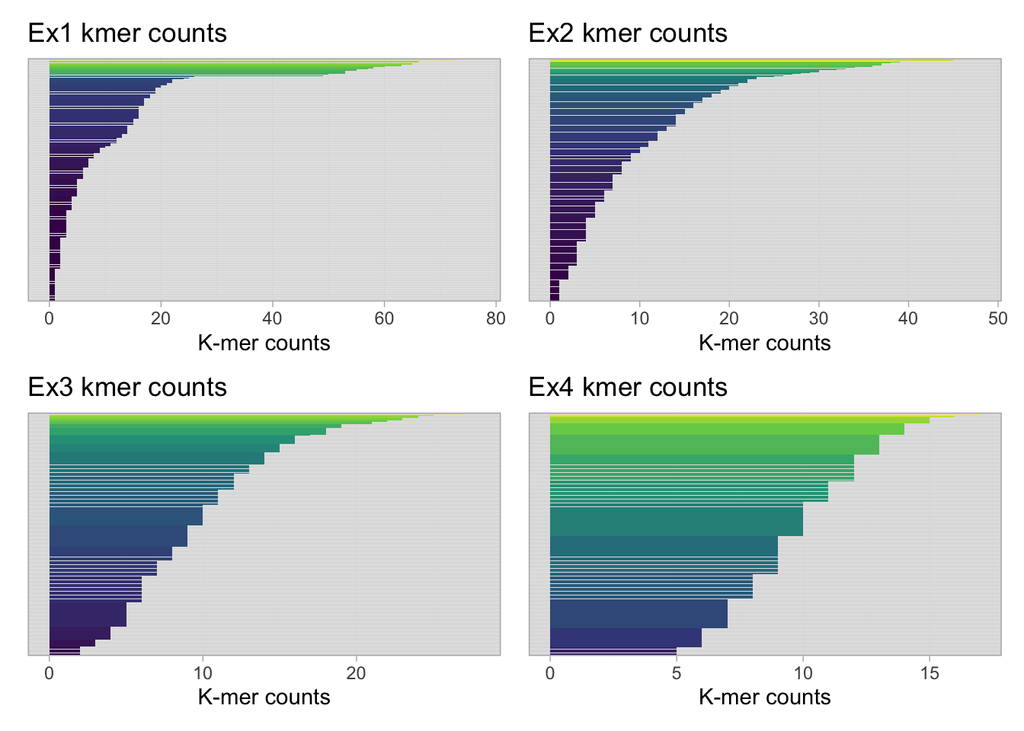

Notably, experiments 1 and 2 are right skewed and experiments 3 and 4 are progressively less so.

## Summary table

The `max count` variation is worth exploring further.

**K-mer counts summary table**

| experiment | median count | mean count | min count | max count |
| --- | --- | --- | --- | --- |
| Exp1_counts | 5 | 11 | 1 | 77 |
| Exp2_counts | 7 | 10 | 1 | 48 |
| Exp3_counts | 9 | 10 | 1 | 28 |
| Exp4_counts | 10 | 10 | 3 | 17 |

## Density plots

We can get a better feeling for the distributions with density plots.

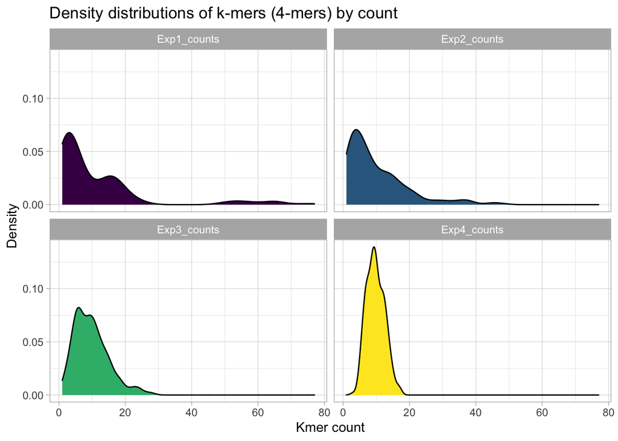

## Binning the kmer counts for a more general pattern

In the next two plots, the k-mer counts are grouped into 8 categories (10-80 k-mer counts by 10 and an other category). For all experiments, most of the 256 possible k-mers appear less than 10 times. So as not to dwarf the k-mer counts that appear more than ten times, it’s better shown separately.

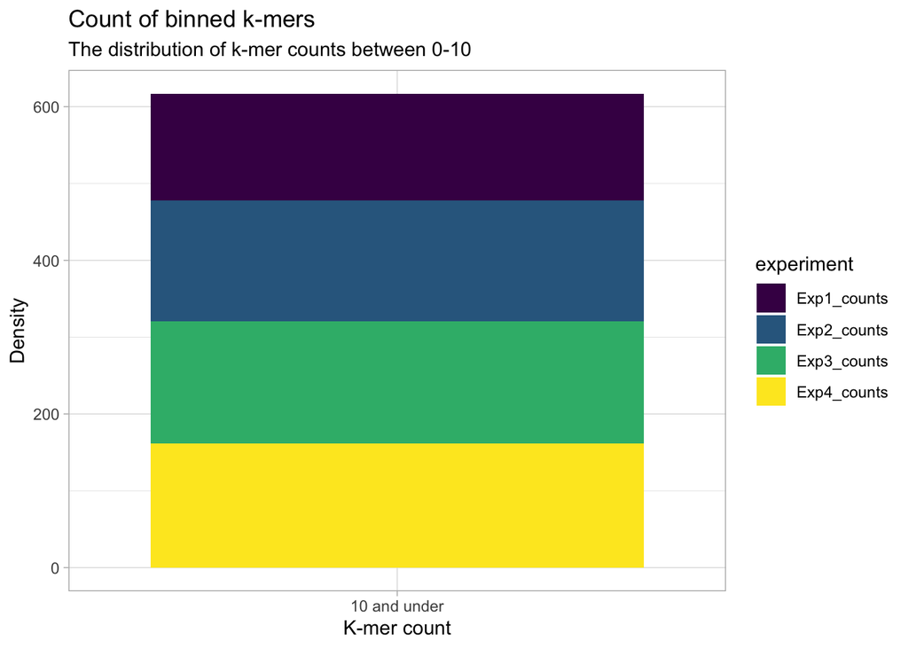

[figure not shown]

We see that experiment 2 dominates k-mer counts in the 30-40 range and experiment 1 dominates in the greater than 40 range.

I hope these plots help you narrow down the culprit behind your experimental variation. Good luck and let me know if you have any questions regarding the command line k-mer counting script.

## Instructions: k-mer counting script for the command line

To help you check for imbalanced k-mer distributions in future experiments, I designed a k-mer counting analysis script that works from the command line. The k-mer counter let’s you input a FASTA file and k-mer length, and returns a tab separated file of k-mer counts ordered by frequency. The program also returns messages about the analysis including:  
- Input sequence length  
- K-mer length  
- Which nonstandard nucleotides the program can identify  
- Whether the k-mer length is acceptable for the sequence range  
- The top 10 k-mers by count  
- Whether the given sequence contains standard or nonstandard nucleotides. The nonstandard nucleotide warning can be tested with the following file: takehome/challenge1/nonstandard_nucs.fasta

To use the k-mer counting tool:  
1. Download the directory I sent you and open it in the command line  
2. Change the permissions for kmer_counter_tool.R script to make it executable on your machine (chmod +x kmer_counter_tool.R)  
3. Then run the following incantation in your command line (with custom input and output file names):  
Rscript kmer_counter_tool.R ‘input_file’ kmer-length –output_file ‘output_file’  
e.g.,

[figure not shown]

4. See the image below for the expected output in the command line (Note: I am working on a mac).  
When running the script, a new output file (tab separated format) with k-mers ordered by frequency is generated.

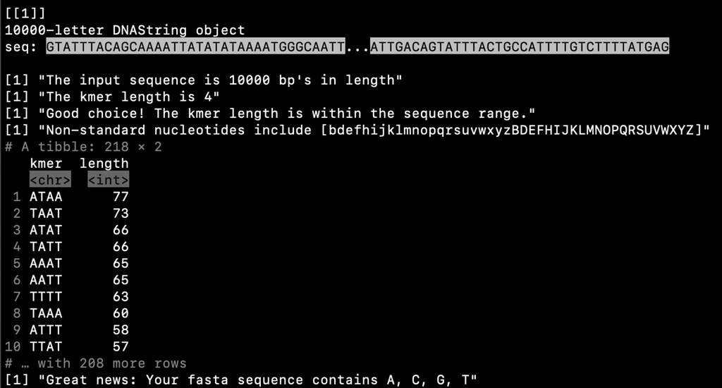